Ullrich Köthe: Fundamentals of Machine Learning, Winter Semester 2018/19

# 2 Precision-Recall Curves

## 2.1 Euclidean Distance

```python
# import modules
import numpy as np
from sklearn.datasets import load_digits
import matplotlib.pyplot as plt
%matplotlib notebook
plt.rcParams.update({'font.size': 12})

import pandas as pd
pd.options.display.float_format = '{:,.2f}'.format

# read and prepare the digits data
digits = load_digits()
data = digits["data"]
target = digits["target"]
# make data subsets for each digit'
data_subsets = [data[target==i] for i in  range(10)]
```

#### Calculate complete precision and recall matrices for whole dataset. Defining class PrecisionRecall to simplify calculations.

```python
class PrecisionRecall:
    def __init__(self, data, target):
        self.data = data
        self.target = target

    def dissimilarity(self):
        # normalize data ||x||==1
        # d(xi,xj)= ||xi-xj||² = ||xi||² +||xj||² - 2*xi*xj = 2 - 2*xi*xj
        # --> for whole dataset D = 2 - 2*dotproduct(data,transposed_data)
        self.data = self.data / np.linalg.norm(self.data, axis=1)[:, None]
        dis = 2 - 2*np.dot(self.data, self.data.T)
        return dis

    def response_set(self):
        self.dis = self.dissimilarity()
        return np.argsort(self.dis, axis=1)

    def get_true_positives(self):
        resp_set = self.response_set()
        tp = np.zeros_like(resp_set)
        for i, row in enumerate(resp_set):
            tp[i, :] = (self.target[row] == target[i])
        self.tp = tp

    def precision_mat(self):
        self.get_true_positives()
        cum_tp = np.cumsum(self.tp, axis=1)
        # cumulative sum along row of tp matrix are tp as function of m
        # TP + FP = m = column index corresponding matrix entry
        precision = cum_tp / (np.arange(data.shape[0]) + 1)[None, :]
        return precision

    def recall_mat(self):
        self.get_true_positives()
        # cumulative sum along row of tp matrix are tp as function of m
        cum_tp = np.cumsum(self.tp, axis=1)
        recall = np.zeros_like(self.tp, dtype='float')
        # calculate total number of digits
        n_samples = np.bincount(self.target)
        for i, row in enumerate(cum_tp):
            recall[i, :] = row / n_samples[target[i]]
        return recall

    @staticmethod
    def classwise_metric(metric):
        # metric is matrix
        labels = np.unique(target)
        class_wise = np.zeros((len(labels), len(target)), dtype='float')
        for label in labels:
            # get indices of data belonging to label y
            # mean of labels of one class gives classwise metric
            label_idx = np.argwhere(target == label).squeeze()
            class_wise[label, :] = np.mean(metric[label_idx, :], axis=0)

        return class_wise

    @staticmethod
    def calc_class_auc(precision, recall):
        n_classes = precision.shape[0]
        auc = np.zeros(n_classes, dtype='float')
        for i in range(n_classes):
            auc[i] = np.trapz(y=precision[i, :][::-1], x=(1-recall[i, :])[::-1])
        return auc

    def gain(self, metric):
        n_samples = np.bincount(self.target)
        N = len(self.target)
        n_ratio = np.repeat((N/n_samples[self.target])[:,None], metric.shape[0], axis=1 )
        gain = (n_ratio-1/metric)/(n_ratio-1)
        gain = np.maximum(np.zeros_like(gain),gain)
        return gain
```

## Plots

```python
pr = PrecisionRecall(data, target)
prec_mat = pr.precision_mat()
rec_mat = pr.recall_mat()

class_precision = pr.classwise_metric(prec_mat)
class_recall = pr.classwise_metric(rec_mat)

class_precision_gain = pr.classwise_metric(pr.gain(prec_mat))
class_recall_gain = pr.classwise_metric(pr.gain(rec_mat))

AUC = pr.calc_class_auc(class_precision, class_recall)
gain_AUC = pr.calc_class_auc(class_precision_gain, class_recall_gain)
```

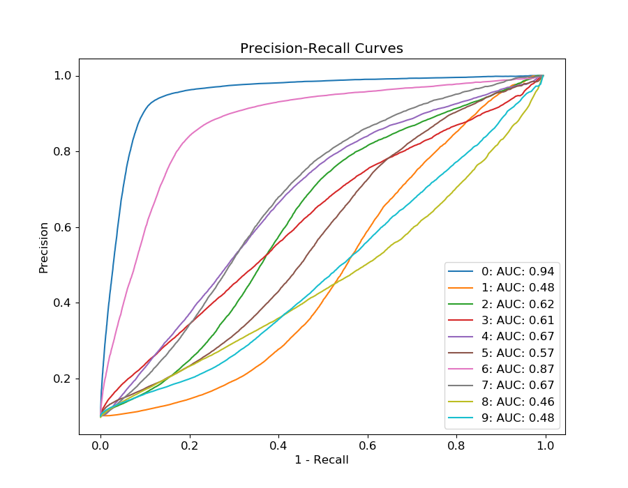

```python
fig, ax = plt.subplots(1, figsize=(9,7))

for i in range(10):
    plt.plot(1-class_recall[i, :], class_precision[i, :], label=('%i: AUC: %.2f' % (i, AUC[i])))
ax.set_xlabel('1 - Recall')
ax.set_ylabel('Precision')
plt.title('Precision-Recall Curves')
plt.legend()
```

Measuring the dissimilarity by using Euclidean Distance exhibits heterogenous performance with respect to different digits. This is to be expected, since some of the digits are geometrically very close, especially in a noisy dataset like digits. The reason why "0" is still performing quite well is probably, that the missing intensity at the very center is relatively unique and there for induces a distance in these dimensions, which make at well distinguishable from other digits.

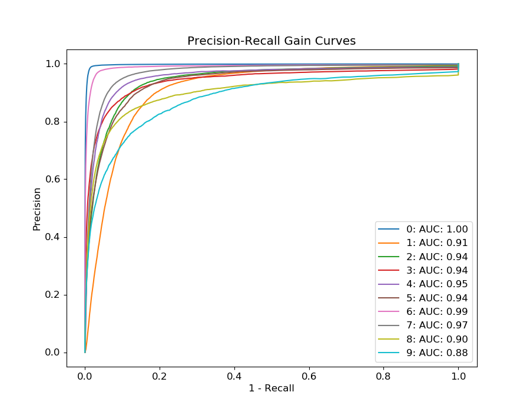

```python
fig, ax = plt.subplots(1, figsize=(9,7))
for i in range(10):
    plt.plot(1-class_recall_gain[i, :], class_precision_gain[i, :], label=('%i: AUC: %.2f' % (i, gain_AUC[i])))
ax.set_xlabel('1 - Recall')
ax.set_ylabel('Precision')
plt.title('Precision-Recall Gain Curves')
plt.legend()
```

## 2.2 Hand-Crafted Distance

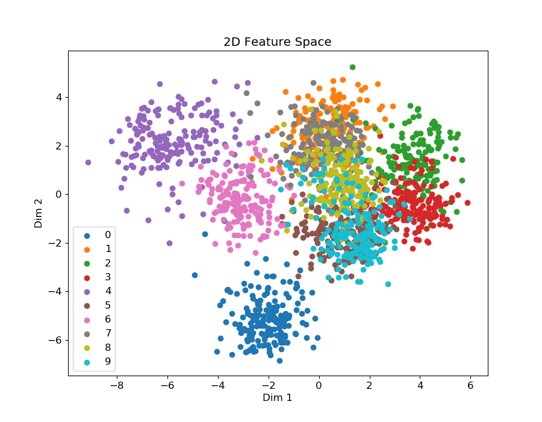

```python
from sklearn.discriminant_analysis import LinearDiscriminantAnalysis
# norm_data = data / np.linalg.norm(data, axis=1)[:, None]
lda = LinearDiscriminantAnalysis(n_components=2)
lda.fit(data, target)
new_features =lda.transform(data)
plt.figure(figsize=(9, 7))
for i in range(10):
    plt.scatter(new_features[target==i, 0], new_features[target==i, 1], label=str(i))
plt.xlabel('Dim 1')
plt.ylabel('Dim 2')
plt.title('2D Feature Space')
plt.legend()
```

The use of LDA here is just exemplary, there are a lot of different ways to perform a dimensionality reduction. Any way the property we're trying to provokewith it in the scatter plot is having as much geometrical distance between classes, while reaching very concentrated class clusters.

```python
pr_2d = PrecisionRecall(new_features, target)
prec_mat_2d = pr.precision_mat()
rec_mat_2d = pr.recall_mat()

class_precision_2d = pr.classwise_metric(prec_mat_2d)
class_recall_2d = pr.classwise_metric(rec_mat_2d)

class_precision_gain_2d = pr.classwise_metric(pr.gain(prec_mat_2d))
class_recall_gain_2d = pr.classwise_metric(pr.gain(rec_mat_2d))

AUC_2d = pr.calc_class_auc(class_precision_2d, class_recall_2d)
gain_AUC_2d = pr.calc_class_auc(class_precision_gain_2d, class_recall_gain_2d)
```

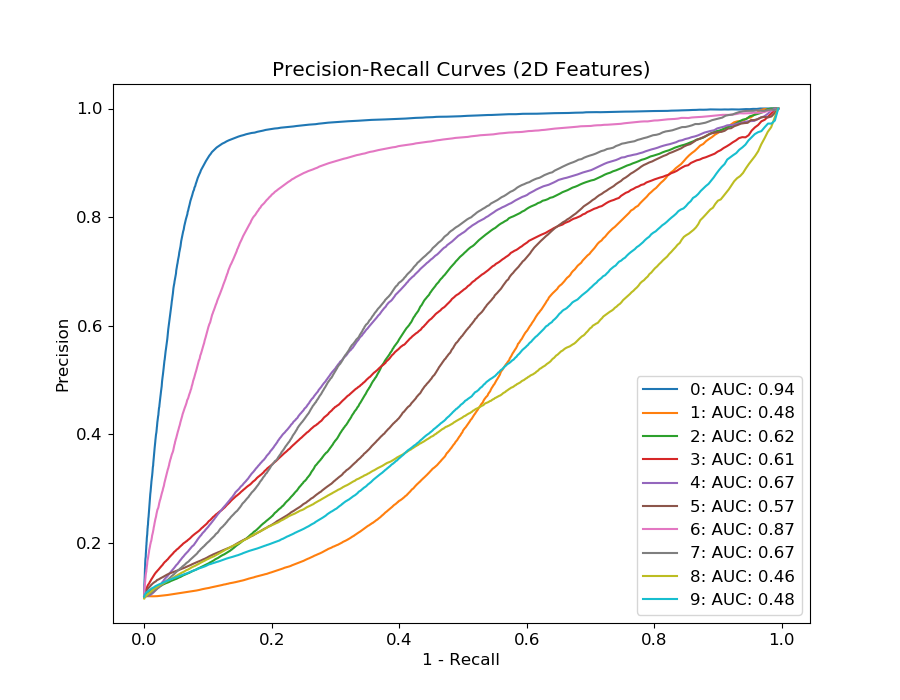

```python
fig, ax = plt.subplots(1, figsize=(9,7))

for i in range(10):
    plt.plot(1-class_recall_2d[i, :], class_precision_2d[i, :], label=('%i: AUC: %.2f' % (i, AUC_2d[i])))
ax.set_xlabel('1 - Recall')
ax.set_ylabel('Precision')
plt.title('Precision-Recall Curves (2D Features)')
plt.legend()
```

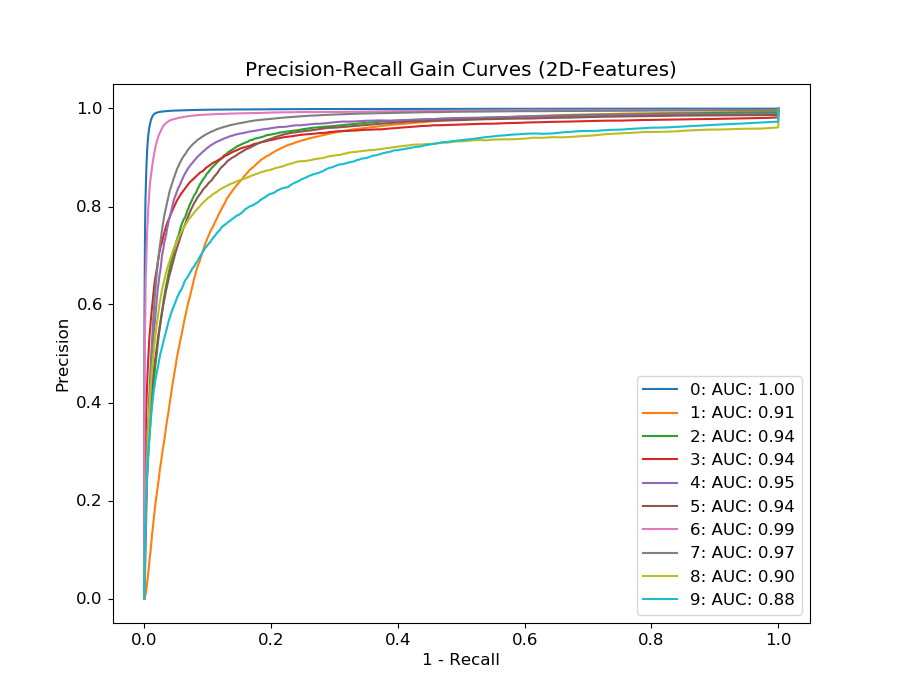

```python
fig, ax = plt.subplots(1, figsize=(9, 7))

for i in range(10):
    plt.plot(1-class_recall_gain_2d[i, :], class_precision_gain_2d[i, :], label=('%i: AUC: %.2f' % (i, gain_AUC_2d[i])))
ax.set_xlabel('1 - Recall')
ax.set_ylabel('Precision')
plt.title('Precision-Recall Gain Curves (2D-Features)')
plt.legend()
```